# track2kba with bbmm example (Storm Island stpe)

ariellenske

2/06/2022

## load packages

```r
library(tidyverse)
library(lubridate)
library(adehabitatHR)
library(sf)
library(sp)
library(raster)
library(spatialEco)
library(track2KBA)
library(patchwork)
```

### load and format data

```r
#load data
gps <- readRDS("data_clean/stpe_gps_data_with_tripID.rds")

#pull out just the Storm Islands data and add id column which combines deployID and trackID
gps <- gps %>% dplyr::filter(location == "Storm") %>%
  mutate(id = paste0(deployID,"_trip",tripID))

#remove missed fixes
gps <- gps %>% dplyr::filter(!is.na(lat))

#make a colony df
colony <- data.frame(Longitude = gps$island_lon[1],
                     Latitude = gps$island_lat[1])

# #remove incomplete trips
# gps <- gps %>% dplyr::filter(completeTrack == 1)

#remove 3 birds with high rates of missing fixes
gps <- gps %>% dplyr::filter(!deployID %in% c("band115186871-tag20793-2019",
                                              "band115186873-tag20906-2019",
                                              "band115186874-tag20809-2019"))

#remove any locations less than 3 km of the colony
gps <- gps %>% dplyr::filter(islandDist >= 3)

#list of trips
blist <- gps %>% dplyr::select(id) %>% distinct() %>% pull()

#list of trip time for each track in minutes
triptime <- gps %>%
  mutate(triptime = as.numeric(gps$lastDetect - gps$firstDetect) * 60) %>%
  dplyr::select(id, triptime) %>%
  distinct() %>%
  dplyr::select(triptime, id)
```

### make a list that contains trip time for each track in minutes

#### used later for calculating a trip length corrected population hotspot raster)

```r
triptime.list <- gps %>%
  mutate(triptime = as.numeric(gps$lastDetect - gps$firstDetect) * 60) %>%
  dplyr::select(id, triptime) %>%
  distinct() %>%
  dplyr::select(triptime) %>%
  pull()
```

### convert dataframe to a sf object

```r
gps.sf <- st_as_sf(gps,
                   coords = c("lon", "lat"),
                   crs = 4326)
```

### project locations from lat lon to equal area projection (BC Albers)

```r
gps.sf <- st_transform(gps.sf, crs = 3153)
```

### format locations as ltraj ‘trajectories’ (adehabitat package)

#### need to do this for function kernelbb

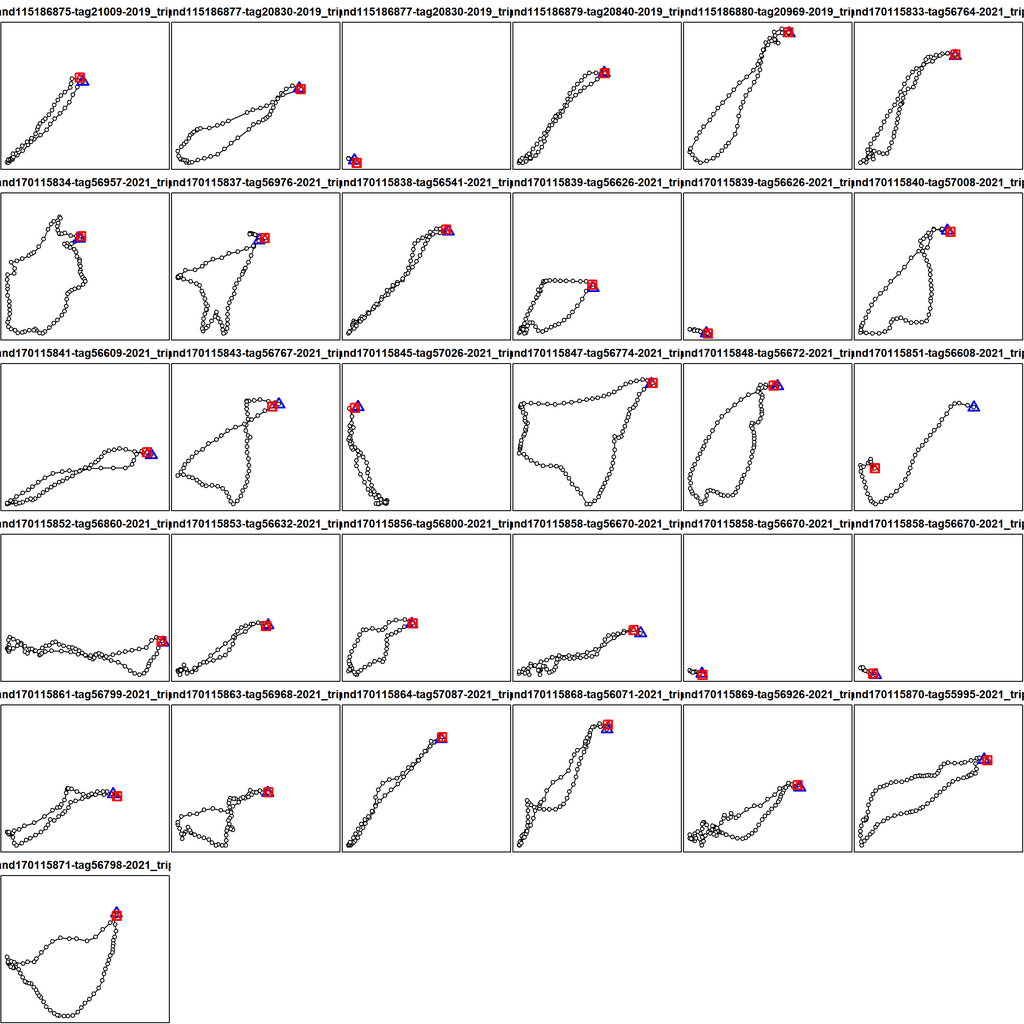

```r
gps.ltraj <- as.ltraj(xy = st_coordinates(gps.sf),
                        date =  gps.sf$ts,
                        id = gps.sf$id)

plot(gps.ltraj)
```

### Also format tracks for track2kba package

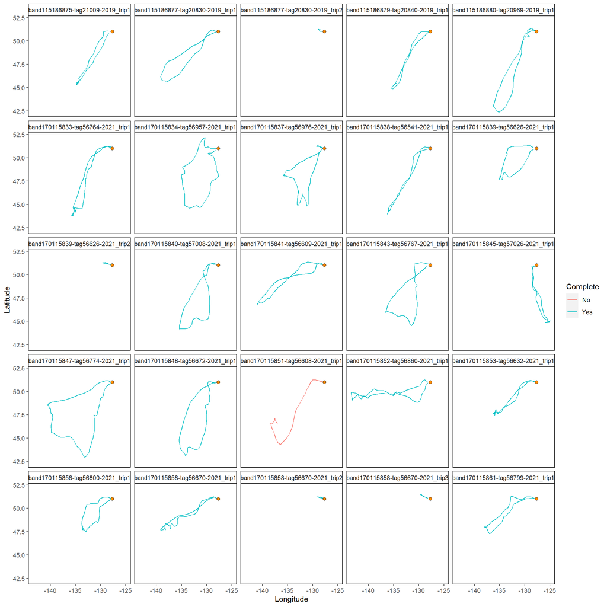

```r
#format for track2kba
gps.kba <- formatFields(
  dataGroup = gps,
  fieldID   = "id",
  fieldDateTime = "ts",
  fieldLon  = "lon",
  fieldLat  = "lat",
  cleanDF = TRUE)

#trip split (should have a small effect since trips have already been identified)
gps.kba <- tripSplit(
  dataGroup  = gps.kba,
  colony     = colony,
  innerBuff  = 3,      # kilometers
  returnBuff = 100,
  duration   = 8,      # hours
  rmNonTrip  = FALSE
)

#trip summary
sumTrips <- tripSummary(trips = gps.kba, colony = colony)

#map trips
mapTrips(trips = gps.kba, colony = colony)
```

```r
#project to equal area
gps.kba <- spTransform(gps.kba, CRS("+init=epsg:3153"))
```

## 1. brownian bridge movement model UDs

### Find the maximum likelihood estimation of the parameter sig1 for each track and save in a list

```r
sig1 <- liker(gps.ltraj, sig2 = 20, rangesig1 = c(50, 300))

#put the values in a list
sig1.list <- unname(unlist(lapply(sig1, function(x) x$sig1)))
```

[figure not shown]

### Calculate range of sig1 values to test

```r
sig1.list0 <- sig1.list
sig1.list4 <- sig1.list * 4
sig1.list8 <- sig1.list * 8
```

### make a grid for the calculation of the UDs

#### this is an easy way to set resolution in terms of m^2 and keep the grid the same for all birds/trips

```r
#bounding box around the tracks
bb <- st_bbox(gps.sf)

#create grid points
# by = pixel size in meters (here I'm using a 5km pixel size, mostly so it doesn't take forever to run)
x <- seq(unname(bb$xmin) - 200000, unname(bb$xmax) + 200000, by = 5000)
y <- seq(unname(bb$ymin) - 200000, unname(bb$ymax) + 200000, by = 5000)
xy <- expand.grid(x=x,y=y)
coordinates(xy) <- ~x+y
proj4string(xy) <- CRS(SRS_string = "EPSG:3153")
gridded(xy) <- TRUE # make into a spatialPixals object
```

### Estimate the brownian bridge UDs

```r
#note: sig2 is location error, here I've input 20, because the Pathtrack gps tags are typically accurate to within ~ 20m.
birdbb.0 <- kernelbb(gps.ltraj, sig1 = sig1.list0, sig2 = 20, grid = xy)
birdbb.4 <- kernelbb(gps.ltraj, sig1 = sig1.list4, sig2 = 20, grid = xy)
birdbb.8 <- kernelbb(gps.ltraj, sig1 = sig1.list8, sig2 = 20, grid = xy)
```

### plot one trip to check

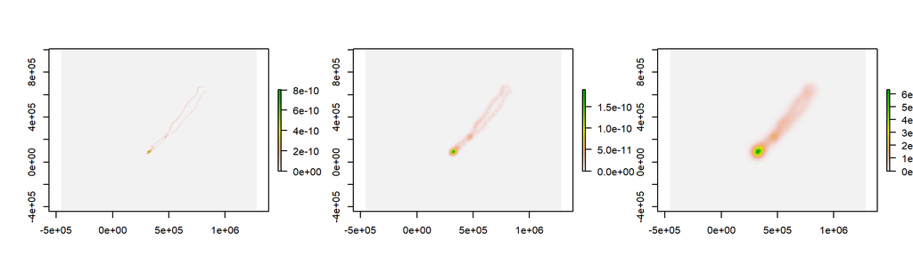

```r
par(mfrow=c(1,3))
plot(raster(as(birdbb.0[[1]], "SpatialPixelsDataFrame")))
plot(raster(as(birdbb.4[[1]], "SpatialPixelsDataFrame")))
plot(raster(as(birdbb.8[[1]], "SpatialPixelsDataFrame")))
```

### Convert adehabitat output format for UDs (estUDm) to a raster and put all the rasters in a rasterstack

```r
raster.list.0 <- lapply(birdbb.0, function(x) (raster(as(x, "SpatialPixelsDataFrame"))))
raster.stack.0 <- stack(raster.list.0)

raster.list.4 <- lapply(birdbb.4, function(x) (raster(as(x, "SpatialPixelsDataFrame"))))
raster.stack.4 <- stack(raster.list.4)

raster.list.8 <- lapply(birdbb.8, function(x) (raster(as(x, "SpatialPixelsDataFrame"))))
raster.stack.8 <- stack(raster.list.8)
```

### Control for trip length

#### These trips cover very different spans of time - some trips are only a single day long vs other are up to 7 days long. We need to control for this before combining all the individual rasters or the short trips will dominate the population level raster. To deal with this I mutlipled the individual trip rasters by their associated trip length in minutes (using the list from earlier)

```r
triptime.list <- triptime %>% dplyr::select(triptime) %>% pull()

raster.stack.adj.0 <- raster.stack.0 * triptime.list
raster.stack.adj.4 <- raster.stack.4 * triptime.list
raster.stack.adj.8 <- raster.stack.8 * triptime.list
```

### Combine individual track rasters into a population level hotspot raster

```r
pop.raster.adj.0 <- calc(raster.stack.adj.0, fun = mean)
pop.raster.adj.4 <- calc(raster.stack.adj.4, fun = mean)
pop.raster.adj.8 <- calc(raster.stack.adj.8, fun = mean)
```

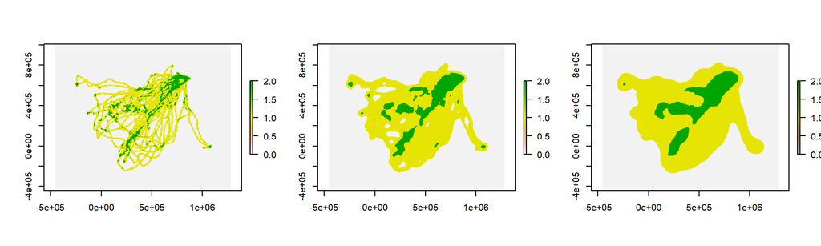

```r
### Population level rasters showing 99% and 50% time
pop.c.0 <- calc(stack(raster.vol(pop.raster.adj.0, p=0.99), raster.vol(pop.raster.adj.0, p=0.50)), fun = sum)
pop.c.4 <- calc(stack(raster.vol(pop.raster.adj.4, p=0.99), raster.vol(pop.raster.adj.4, p=0.50)), fun = sum)
pop.c.8 <- calc(stack(raster.vol(pop.raster.adj.8, p=0.99), raster.vol(pop.raster.adj.8, p=0.50)), fun = sum)

par(mfrow=c(1,3))
plot(pop.c.0)
plot(pop.c.4)
plot(pop.c.8)
```

## 2. track2kba

### get step 99% and 50% UDs for comparison with bbmm output

```r
#smoothing parameter options
hVals <- findScale(
  tracks = gps.kba,
  scaleARS = FALSE,
  sumTrips = sumTrips)

hVals
```

```
##   med_max_dist step_length  mag   href scaleARS
## 1       888.81       33.68 6.79 108.48       NA
```

```r
#step 99
kde99step <- estSpaceUse(
  tracks = gps.kba,
  res = 5,
  scale = hVals$step,
  levelUD = 99,
  polyOut = FALSE
)

#step 50
kde50step <- estSpaceUse(
  tracks = gps.kba,
  res = 5,
  scale = hVals$step,
  levelUD = 50,
  polyOut = FALSE
)

#href 99
kde99href <- estSpaceUse(
  tracks = gps.kba,
  res = 5,
  scale = hVals$href,
  levelUD = 99,
  polyOut = FALSE
)

#href 50
kde50href <- estSpaceUse(
  tracks = gps.kba,
  res = 5,
  scale = hVals$href,
  levelUD = 50,
  polyOut = FALSE
)
```

### track2kba repressentativeness tests

```r
#little function for doing the plotting separately
repPlot <- function(df, title.str) {

  df1 <- df[[1]]
  df2 <- df[[2]]

  P2 <- df2 %>% group_by(.data$SampleSize) %>% dplyr::summarise(meanPred = mean(na.omit(.data$pred)),
                                                                sdInclude = sd(.data$InclusionRate))

  plot(InclusionRate ~ SampleSize, data = df2, pch = 16,
       cex = 0.2, col = "darkgray", ylim = c(0,1), xlim = c(0, max(unique(df2$SampleSize))),
       ylab = "Inclusion", xlab = "Sample Size")

  points(InclusionRate ~ SampleSize, data = df2,
         pch = 16, cex = 0.2, col = "darkgray")

  lines(P2, lty = 1, lwd = 2)

  text(x = 0, y = 0.99, paste(round(df1$out,
                                    1), "%", sep = ""), cex = 2, col = "gray45",
       adj = 0)

  title(title.str)
}

r99bb.0 <- repAssess(
  tracks    = gps.kba,
  KDE       = birdbb.0,
  levelUD   = 99,
  iteration = 20,
  bootTable = TRUE)
```

```r
r50bb.0 <- repAssess(
  tracks    = gps.kba,
  KDE       = birdbb.0,
  levelUD   = 50,
  iteration = 20,
  bootTable = TRUE)
```

```r
r99bb.4 <- repAssess(
  tracks    = gps.kba,
  KDE       = birdbb.4,
  levelUD   = 99,
  iteration = 20,
  bootTable = TRUE)
```

```r
r50bb.4 <- repAssess(
  tracks    = gps.kba,
  KDE       = birdbb.4,
  levelUD   = 50,
  iteration = 20,
  bootTable = TRUE)
```

```r
r99bb.8 <- repAssess(
  tracks    = gps.kba,
  KDE       = birdbb.8,
  levelUD   = 99,
  iteration = 20,
  bootTable = TRUE)
```

```r
r50bb.8 <- repAssess(
  tracks    = gps.kba,
  KDE       = birdbb.8,
  levelUD   = 50,
  iteration = 20,
  bootTable = TRUE)
```

```r
r99step <- repAssess(
  tracks    = gps.kba,
  KDE       = kde99step,
  levelUD   = 99,
  iteration = 20,
  bootTable = TRUE)
```

```r
r50step <- repAssess(
  tracks    = gps.kba,
  KDE       = kde50step,
  levelUD   = 50,
  iteration = 20,
  bootTable = TRUE)
```

```r
r99href <- repAssess(
  tracks    = gps.kba,
  KDE       = kde99href,
  levelUD   = 99,
  iteration = 20,
  bootTable = TRUE)
```

```r
r50href <- repAssess(
  tracks    = gps.kba,
  KDE       = kde50href,
  levelUD   = 50,
  iteration = 20,
  bootTable = TRUE)
```

### repAssess plots

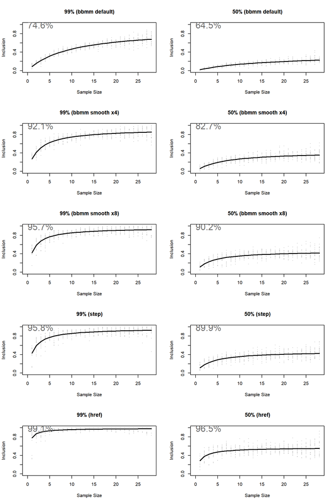

```r
par(mfrow = c(5,2))
repPlot(df = r99bb.0, t = "99% (bbmm default)")
repPlot(df = r50bb.0, t = "50% (bbmm default)")
repPlot(df = r99bb.4, t = "99% (bbmm smooth x4)")
repPlot(df = r50bb.4, t = "50% (bbmm smooth x4)")
repPlot(df = r99bb.8, t = "99% (bbmm smooth x8)")
repPlot(df = r50bb.8, t = "50% (bbmm smooth x8)")
repPlot(df = r99step, t = "99% (step)")
repPlot(df = r50step, t = "50% (step)")
repPlot(df = r99href, t = "99% (href)")
repPlot(df = r50href, t = "50% (href)")
```

### track2kba population scale up

```r
Site99b.0 <- findSite(
  KDE = birdbb.0,
  represent = r99bb.0[[1]]$out,
  popSize = 200000,
  levelUD = 99,
  polyOut = TRUE
)

Site50b.0 <- findSite(
  KDE = birdbb.0,
  represent = r50bb.0[[1]]$out,
  popSize = 200000,
  levelUD = 50,
  polyOut = TRUE
)

Site99b.4 <- findSite(
  KDE = birdbb.4,
  represent = r99bb.4[[1]]$out,
  popSize = 200000,
  levelUD = 99,
  polyOut = TRUE
)

Site50b.4 <- findSite(
  KDE = birdbb.4,
  represent = r50bb.4[[1]]$out,
  popSize = 200000,
  levelUD = 50,
  polyOut = TRUE
)

Site99b.8 <- findSite(
  KDE = birdbb.8,
  represent = r99bb.8[[1]]$out,
  popSize = 200000,
  levelUD = 99,
  polyOut = TRUE
)

Site50b.8 <- findSite(
  KDE = birdbb.8,
  represent = r50bb.8[[1]]$out,
  popSize = 200000,
  levelUD = 50,
  polyOut = TRUE
)

Site99step <- findSite(
  KDE = kde99step,
  represent = r99step[[1]]$out,
  popSize = 200000,
  levelUD = 99,
  polyOut = TRUE
)

Site50step <- findSite(
  KDE = kde50step,
  represent = r50step[[1]]$out,
  popSize = 200000,
  levelUD = 50,
  polyOut = TRUE
)

Site99href <- findSite(
  KDE = kde99href,
  represent = r99href[[1]]$out,
  popSize = 200000,
  levelUD = 99,
  polyOut = TRUE
)

Site50href <- findSite(
  KDE = kde50href,
  represent = r50href[[1]]$out,
  popSize = 200000,
  levelUD = 50,
  polyOut = TRUE
)
```

### Population maps (define area used by at least 10% of the population)

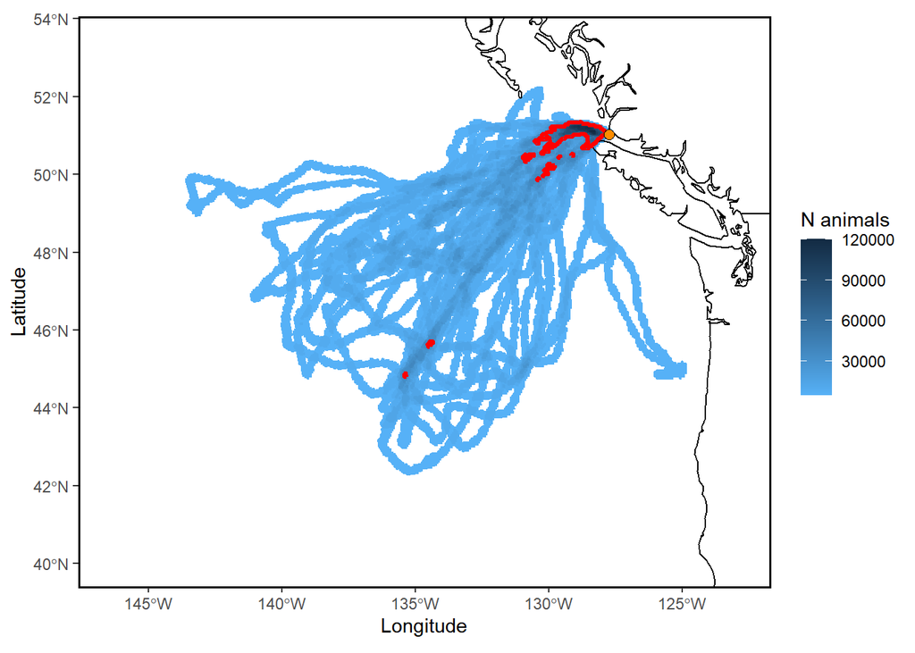

```r
p1 <- mapSite(Site99b.0, colony = colony) + ggtitle("99% (bbmm default)")
```

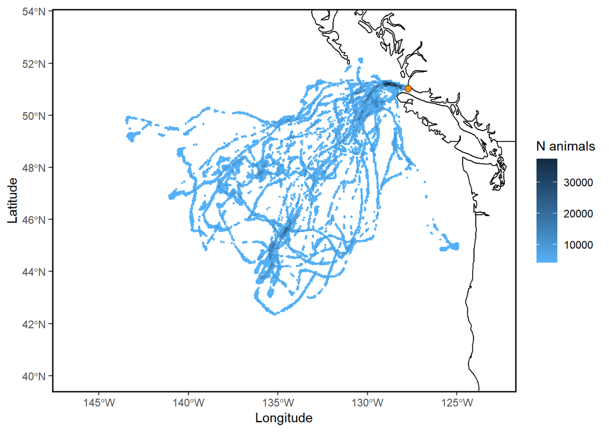

```r
p2 <- mapSite(Site50b.0, colony = colony) + ggtitle("50% (bbmm default)")
```

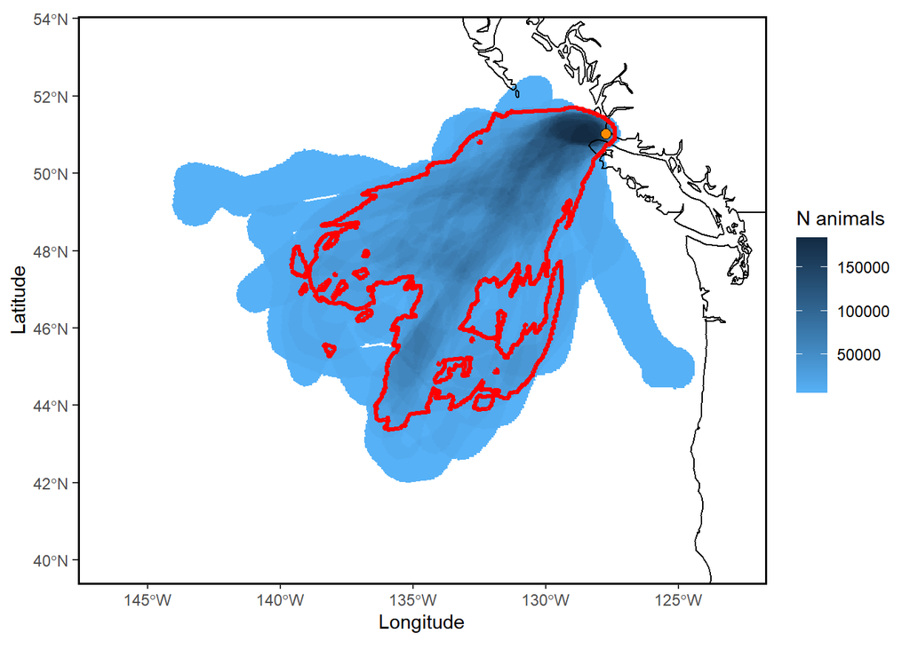

```r
p3 <- mapSite(Site99b.4, colony = colony) + ggtitle("99% (bbmm smooth x4)")
```

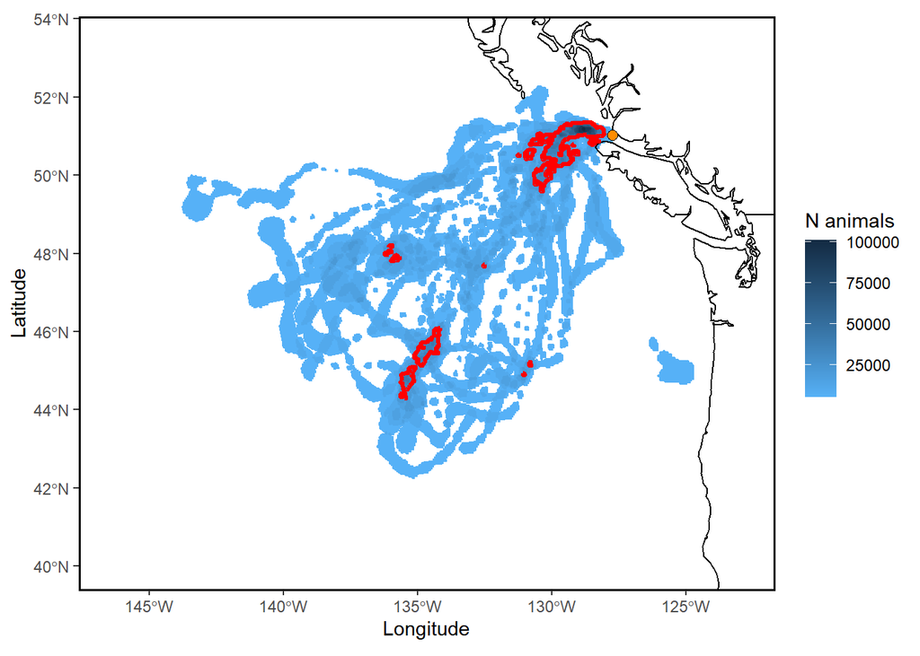

```r
p4 <- mapSite(Site50b.4, colony = colony) + ggtitle("50% (bbmm smooth x4)")
```

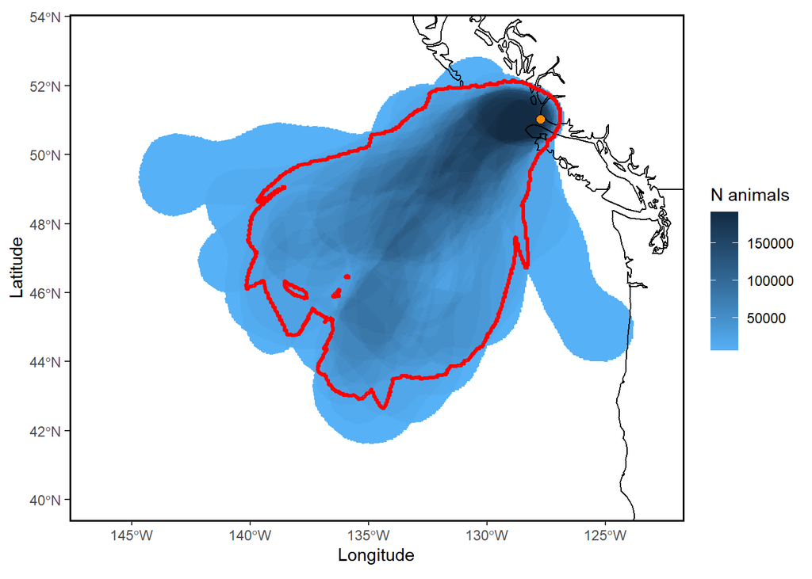

```r
p5 <- mapSite(Site99b.8, colony = colony) + ggtitle("99% (bbmm smooth x8)")
```

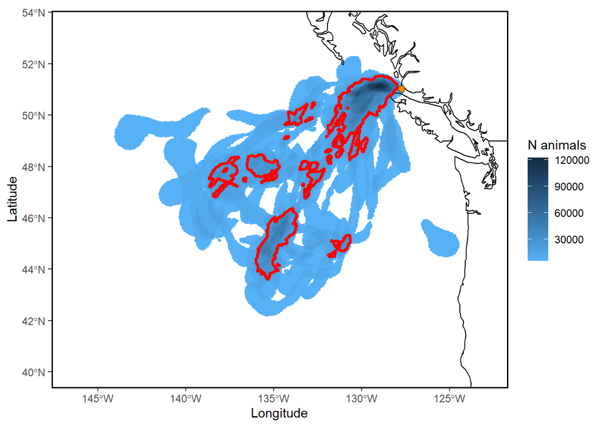

```r
p6 <- mapSite(Site50b.8, colony = colony) + ggtitle("50% (bbmm smooth x8)")
```

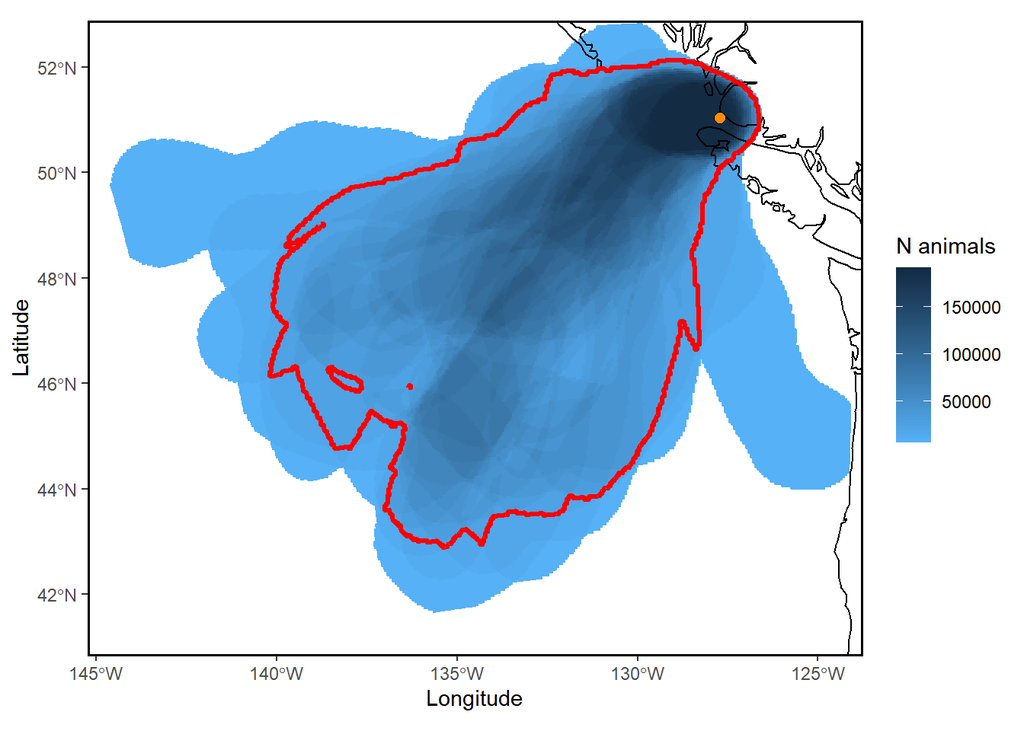

```r
p7 <- mapSite(Site99step, colony = colony) + ggtitle("99% (kde step)")
```

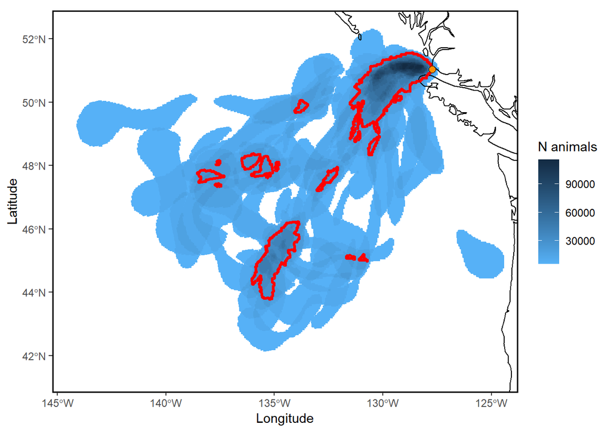

```r
p8 <- mapSite(Site50step, colony = colony) + ggtitle("50% (kde step)")
```

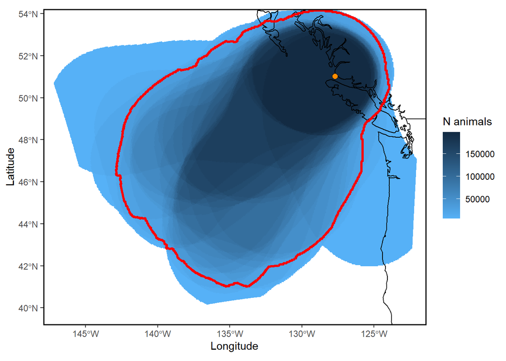

```r
p9 <- mapSite(Site99href, colony = colony) + ggtitle("99% (kde href)")
```

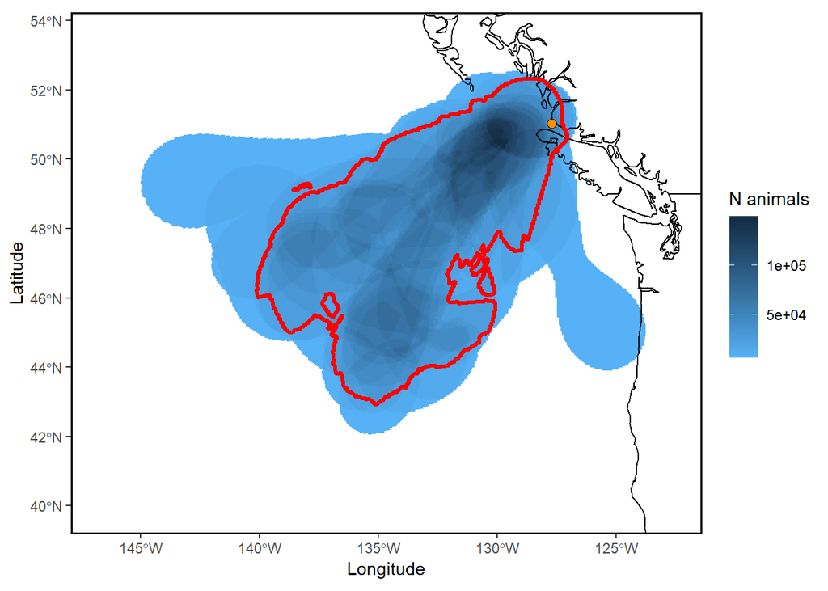

```r
p10 <- mapSite(Site50href, colony = colony) + ggtitle("50% (kde href)")
```

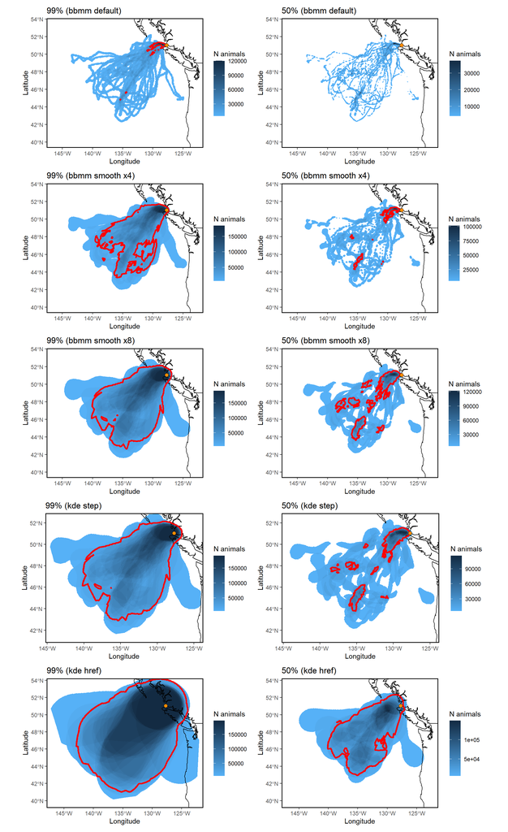

```r
(p1 | p2 ) / (p3 | p4) / (p5 | p6) / (p7 | p8) / (p9 | p10)
```

### look at relationship between relocations and UD estimates

```r
v99.0 <- getverticeshr(birdbb.0[[8]], percent = 99) %>%
  st_as_sf() %>%
  mutate(ud.type = "99% (bbmm default)")

v50.0 <- getverticeshr(birdbb.0[[8]], percent = 50) %>%
  st_as_sf() %>%
  mutate(ud.type = "50% (bbmm default)")

v99.4 <- getverticeshr(birdbb.4[[8]], percent = 99) %>%
  st_as_sf() %>%
  mutate(ud.type = "99% (bbmm smooth x4)")

v50.4 <- getverticeshr(birdbb.4[[8]], percent = 50) %>%
  st_as_sf() %>%
  mutate(ud.type = "50% (bbmm smooth x4)")

v99.8 <- getverticeshr(birdbb.8[[8]], percent = 99) %>%
  st_as_sf() %>%
  mutate(ud.type = "99% (bbmm smooth x8)")

v50.8 <- getverticeshr(birdbb.8[[8]], percent = 50) %>%
  st_as_sf() %>%
  mutate(ud.type = "50% (bbmm smooth x8)")

v99.step <- getverticeshr(kde99step[[8]], percent = 99) %>%
  st_as_sf() %>%
  mutate(ud.type = "99% (kde step)")

v50.step <- getverticeshr(kde50step[[8]], percent = 50) %>%
  st_as_sf() %>%
  mutate(ud.type = "50% (kde step)")

v99.href <- getverticeshr(kde99href[[8]], percent = 99) %>%
  st_as_sf() %>%
  mutate(ud.type = "99% (kde href)")

v50.href <- getverticeshr(kde50href[[8]], percent = 50) %>%
  st_as_sf() %>%
  mutate(ud.type = "50% (kde href)")


test <- rbind(v99.0, v50.0, v99.4, v50.4, v99.8, v50.8, v99.step, v50.step, v99.href, v50.href)
```

### Plot

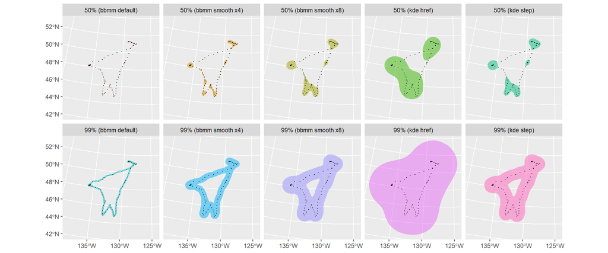

```r
ggplot() +
  geom_sf(data = test, aes(fill = ud.type), color = NA, alpha = 0.5) +
  geom_sf(data = gps.sf %>% dplyr::filter(id == blist[8]), size = 0.2, color = "black") +
  facet_wrap(~ud.type, ncol = 5) +
  theme(legend.position = "none")
```